# Simple Visualization on Goodreads-books

**Author:** *Zhanglin Liu*

**Date:** *September 05, 2020*

# 1 Background

The dataset used in this project is a Kaggle open dataset named [Goodreads-books](https://www.kaggle.com/jealousleopard/goodreadsbooks). It provides a comprehensive list of all books listed in goodreads. This dataset was last updated on March 09, 2020.

We are trying to answer the following questions:

- Which top 5 books have the highest average rating and from which publisher?
- How many books were published since 1990?

# 2 Data Preparation

There are 4 lines with unmatched column size, to successfully load using pandas, these 4 lines are skipped.

```python
import warnings
warnings.filterwarnings('ignore')
import pandas as pd
from matplotlib import pyplot as plt
plt.style.use('ggplot')
df = pd.read_csv('C:/Users/Elle/Desktop/jupyter_folder/datasets/books.csv', error_bad_lines = False)
df.head()
```

```
b'Skipping line 3350: expected 12 fields, saw 13\nSkipping line 4704: expected 12 fields, saw 13\nSkipping line 5879: expected 12 fields, saw 13\nSkipping line 8981: expected 12 fields, saw 13\n'
```

|  | bookID | title | authors | average_rating | isbn | isbn13 | language_code | num_pages | ratings_count | text_reviews_count | publication_date | publisher |
| --- | --- | --- | --- | --- | --- | --- | --- | --- | --- | --- | --- | --- |
| 0 | 1 | Harry Potter and the Half-Blood Prince (Harry ... | J.K. Rowling/Mary GrandPré | 4.57 | 0439785960 | 9780439785969 | eng | 652 | 2095690 | 27591 | 9/16/2006 | Scholastic Inc. |
| 1 | 2 | Harry Potter and the Order of the Phoenix (Har... | J.K. Rowling/Mary GrandPré | 4.49 | 0439358078 | 9780439358071 | eng | 870 | 2153167 | 29221 | 9/1/2004 | Scholastic Inc. |
| 2 | 4 | Harry Potter and the Chamber of Secrets (Harry... | J.K. Rowling | 4.42 | 0439554896 | 9780439554893 | eng | 352 | 6333 | 244 | 11/1/2003 | Scholastic |
| 3 | 5 | Harry Potter and the Prisoner of Azkaban (Harr... | J.K. Rowling/Mary GrandPré | 4.56 | 043965548X | 9780439655484 | eng | 435 | 2339585 | 36325 | 5/1/2004 | Scholastic Inc. |
| 4 | 8 | Harry Potter Boxed Set Books 1-5 (Harry Potte... | J.K. Rowling/Mary GrandPré | 4.78 | 0439682584 | 9780439682589 | eng | 2690 | 41428 | 164 | 9/13/2004 | Scholastic |

## 2.1 The Dataset

The following provides a basic information on the interested dataset. Below shows that there are 11,123 entries.

```python
df['bookID'].nunique()
```

```
11123
```

```python
df.info()
```

```
<class 'pandas.core.frame.DataFrame'>
RangeIndex: 11123 entries, 0 to 11122
Data columns (total 12 columns):
 #   Column              Non-Null Count  Dtype
---  ------              --------------  -----
 0   bookID              11123 non-null  int64
 1   title               11123 non-null  object
 2   authors             11123 non-null  object
 3   average_rating      11123 non-null  float64
 4   isbn                11123 non-null  object
 5   isbn13              11123 non-null  int64
 6   language_code       11123 non-null  object
 7     num_pages         11123 non-null  int64
 8   ratings_count       11123 non-null  int64
 9   text_reviews_count  11123 non-null  int64
 10  publication_date    11123 non-null  object
 11  publisher           11123 non-null  object
dtypes: float64(1), int64(5), object(6)
memory usage: 1.0+ MB
```

## 2.2 Data Cleaning

Notice the data type of 'publication_date' column is type object, since we are going to work with dates, it is better to convert the data type to datetime format.

```python
df['publication_date'] = pd.to_datetime(df['publication_date'], format='%m/%d/%Y', errors='coerce')
df.info()
```

```
<class 'pandas.core.frame.DataFrame'>
RangeIndex: 11123 entries, 0 to 11122
Data columns (total 12 columns):
 #   Column              Non-Null Count  Dtype
---  ------              --------------  -----
 0   bookID              11123 non-null  int64
 1   title               11123 non-null  object
 2   authors             11123 non-null  object
 3   average_rating      11123 non-null  float64
 4   isbn                11123 non-null  object
 5   isbn13              11123 non-null  int64
 6   language_code       11123 non-null  object
 7     num_pages         11123 non-null  int64
 8   ratings_count       11123 non-null  int64
 9   text_reviews_count  11123 non-null  int64
 10  publication_date    11121 non-null  datetime64[ns]
 11  publisher           11123 non-null  object
dtypes: datetime64[ns](1), float64(1), int64(5), object(5)
memory usage: 1.0+ MB
```

# 3 Simple Statistics

## 3.1 Top 5 books with the highest average rating and from which publisher?

To taking into account that some books may have a few rating counts but high reivews, we will be only considering books with at least 50 reviews.

```python
tempDf = df.loc[df['ratings_count'] >= 50]
hi_avg_rating = tempDf.groupby(['title','publisher'])['average_rating'].max().sort_values(ascending=False).head(5).reset_index()
hi_avg_rating
```

|  | title | publisher | average_rating |
| --- | --- | --- | --- |
| 0 | The Complete Calvin and Hobbes | Andrews McMeel Publishing | 4.82 |
| 1 | Harry Potter Boxed Set Books 1-5 (Harry Potte... | Scholastic | 4.78 |
| 2 | It's a Magical World (Calvin and Hobbes #11) | Andrews McMeel Publishing | 4.76 |
| 3 | Early Color | Steidl | 4.73 |
| 4 | Harry Potter Collection (Harry Potter #1-6) | Scholastic | 4.73 |

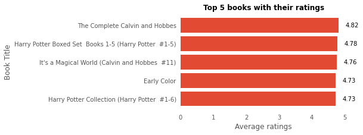

```python
fig, ax = plt.subplots(figsize = (5,3))
ax.set_title('Top 5 books with their ratings', fontsize = 12, weight = 'bold')
ax.set_ylabel('Book Title')
ax.set_xlabel('Average ratings')
ax.barh(hi_avg_rating['title'],hi_avg_rating['average_rating'])
for i in ['top','bottom','left','right']:
    ax.spines[i].set_visible(False)
ax.xaxis.set_ticks_position('none')
ax.yaxis.set_ticks_position('none')
ax.grid(False)
ax.set_facecolor("white")
ax.invert_yaxis()
for j in ax.patches:
    plt.text(j.get_width()+0.2, j.get_y()+0.5,
             str(round((j.get_width()),2)), fontsize = 10, color = 'black')
plt.show()
```

## 3.2 How many books were published since 1990?

As shown below, 10,168 unique books were published since year 1990. A 'publication_year' column is added to provide a better visualization chart.

```python
df_pub = df.loc[df['publication_date'] >= '01/01/1990']
df_pub['publication_year'] = pd.DatetimeIndex(df_pub['publication_date']).year
df_pub.shape
```

```
(10168, 13)
```

```python
df_pub_temp = df_pub.groupby(['publication_year'])['bookID'].count().reset_index()
df_pub_temp
```

|  | publication_year | bookID |
| --- | --- | --- |
| 0 | 1990 | 117 |
| 1 | 1991 | 151 |
| 2 | 1992 | 183 |
| 3 | 1993 | 165 |
| 4 | 1994 | 220 |
| 5 | 1995 | 249 |
| 6 | 1996 | 250 |
| 7 | 1997 | 290 |
| 8 | 1998 | 396 |
| 9 | 1999 | 450 |
| 10 | 2000 | 533 |
| 11 | 2001 | 656 |
| 12 | 2002 | 798 |
| 13 | 2003 | 931 |
| 14 | 2004 | 1069 |
| 15 | 2005 | 1260 |
| 16 | 2006 | 1700 |
| 17 | 2007 | 518 |
| 18 | 2008 | 49 |
| 19 | 2009 | 42 |
| 20 | 2010 | 37 |
| 21 | 2011 | 24 |
| 22 | 2012 | 21 |
| 23 | 2013 | 15 |
| 24 | 2014 | 9 |
| 25 | 2015 | 10 |
| 26 | 2016 | 6 |
| 27 | 2017 | 7 |
| 28 | 2018 | 5 |
| 29 | 2019 | 6 |
| 30 | 2020 | 1 |

```python
df_pub_temp.describe()
```

|  | publication_year | bookID |
| --- | --- | --- |
| count | 31.000000 | 31.000000 |
| mean | 2005.000000 | 328.000000 |
| std | 9.092121 | 427.870541 |
| min | 1990.000000 | 1.000000 |
| 25% | 1997.500000 | 18.000000 |
| 50% | 2005.000000 | 165.000000 |
| 75% | 2012.500000 | 484.000000 |
| max | 2020.000000 | 1700.000000 |

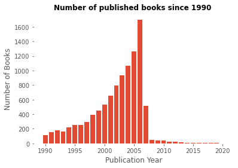

```python
fig_pub, ax_pub = plt.subplots()
fig_pub = plt.figure(figsize = (5,3))
ax_pub.set_title('Number of published books since 1990 ', fontsize = 12, weight = 'bold')
ax_pub.set_xlabel('Publication Year')
ax_pub.set_ylabel('Number of Books')
ax_pub.grid(False)
ax_pub.set_facecolor("white")
ax_pub.bar(df_pub_temp['publication_year'],df_pub_temp['bookID'])
plt.show()
```

One interesting observation from the above bar chart is that the rate at which the books were published was at an increasing slope between 1990 to 2006. At around 2007, the slope started to decline.